# PISA2012_wenchit

## Abstract

In this research, I want to explore the education resource distribution in Australia. For insatnce, comparing the education resources between remote and city areas and the discrepancies between private or public schools. Based on the PISA2012 mathematics literacy survey data. Also, I will break down the the relationship between school location and how it relates to the scores in math literacy, the relationship between private or public schools and how it relates to the students’ scores in math literacy.

# Introduction

- PISA2012: the term PISA stands for Programme for International Student Assessment is a survey that randomly select 15 year-old students(students who are attending secondary schools) as samples for assessment. In 2012, a total of 65 OECD countries and economics and about half a million 15 year-old students participated in the PISA assessment. Generally, the assessed reaults lies in 5 categories: Level 5 are high performers, whereas students who lies below the international standard baseline level 2 are cosidered low performers. In 2012, 775 Australian schools and 14,481 studnets participated in this assessment. To ensure the authenticity, an amount of indigenous students were also sampled.
- Students are categorized in 6 different levels in accordance to their proficiency in the assessment(PISA, 2012):
- Level 6: can conceptualise, generalise and use information. They are capable of advanced mathematical thinking and reasoning; have a mastery of symbolic and formal mathematical operations and relationships; and can formulate and precisely communicate their ndings, interpretations and arguments. Students who score higher than 669.3 scores belongs to level6.
- Level 5: can develop and work with models for complex situations; select, compare and evaluate appropriate problem-solving strategies for dealing with complex problems; work strategically using broad, well-developed thinking and reasoning skills; and re ect on their work and formulate and communicate their interpretations and reasoning. Students who score higher than 607.0 scores belongs to level5.
- Level 4: can work effectively with explicit models for complex, concrete situations; select and integrate different representations, including symbolic representations; utilise their skills and reason with insight; and construct and communicate explanations and arguments. Students who score higher than 544.7 scores belongs to level4.
- Level 3: can execute clearly described procedures, including those that require sequential decisions; select and apply simple problem-solving strategies; interpret and use representations; typically show some ability to handle percentages, fractions and decimal numbers, and to work with proportional relationships; and provide solutions that re ect that they have engaged in basic interpretation and reasoning. Students who score higher than 482.4 scores belongs to level3.
- Level 2: can interpret and recognise situations in contexts that require no more than direct inference; extract relevant information from a single source and make use of a single representational mode; employ basic algorithms, formulas, procedures or conventions to solve problems involving whole numbers; and make literal interpretations of the results. Students who score higher than 420.1 scores belongs to level2.
- Level 1: can answer questions involving familiar contexts where all relevant information is present and the questions are clearly de ned; identify information and carry out routine procedures; and perform actions that are almost always obvious and follow immediately from the given stimuli. Students who score higher than 357.8 scores belongs to level1.
- Below 1: not demonstrate even the most basic types of mathematical literacy that PISA measures. These students are likely to be seriously disadvantaged in their lives beyond school.
- Mathematic Literacy: in the mathematic literacy domain, the assessment focused on students’ ability to solve mathematic problems described in a real-life situation. In PISA2012 framework(OECD2012, p25), it defined mathematic literacy as follows: “Mathematic literacy is an individual’s capacity to formulate, employ and interpret mathematics in a variety of contexts. It includes reasoning mathematically nd using mathematical concepts, procedures, facts and tools to describe, explain and predict phenomena. It assists individuals to recognise the role that Mathematics plays in the world and to make the well-founded judgments and decisions needed by constructive, engaged and reflective citizens.”

The assessment in math literacy is designed according three main components: 1. the context of a challenge or problem that arises in the real world 2. the nature of mathematical thought and action that can be used to solve the problem 3. the processes that the problem solver can use to construct a solution.

# Overview of Australian Education System:

–Terms and definition It is defined in the handbook from PISA that, Village School or Rural Area: less than 3,000 people Small Town School: 3,000 to about 15,000 people Town School: 15,000 to about 100,000 people City School: 100,000 to about 1,000,000 people, for example, Hobart, Tasmania Large City School: ith over 1,000,000 people, for example, Sydney and Melbourne

–Facts 1. In 2016, there are over 9,400 schools in which 1400 of them are secondary schools across Australia. Which means more than half of the amount of secondary schools were participants of PISA2012 assessment.

2. In 2016, there are over 6,000 government(public) schools, more than 1700 Catholic schools(private) and more than 1,000 independent schools(private)
3. In 2017, around 65% of students attended government school, 19% students attended Catholic schools and 16% students attended independent schools.

# Methods Used

## Results

```r
library(data.table)
library(ggplot2)
library(PISA2012lite)
library("dplyr")
library(lme4)
data("school2012")
setDT(school2012)
data("computerStudent2012")
setDT(computerStudent2012)

#calculate the weighted average of the Math Literacy performance using PV1MATH to PV5MATH
pv_cols <- paste0("PV", 1:5, "MATH")
student_data <- computerStudent2012[NC == "Australia",
                                    lapply(.SD, weighted.mean, w = W_FSTUWT / sum(W_FSTUWT)),
                                    by = SCHOOLID, .SDcols = c(pv_cols, "ESCS") ][, .(SCHOOLID, ESCS,
                                                                       Mean_PVMATH = Reduce(`+`, .SD) / length(.SD)),
                                                                       .SDcols = pv_cols]
#a summary table showing the overall mean math score
student_data[,  .(mu = mean(Mean_PVMATH, na.rm = T), sigma = sd(Mean_PVMATH, na.rm = T))]
```

| mu | sigma |
| --- | --- |
| 495.5452 | 59.07824 |

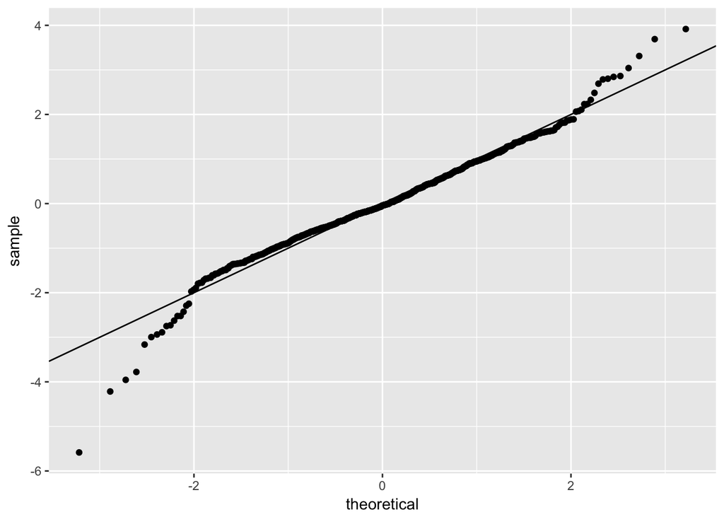

```r
#test whether the data is normally distributed
#' Put data onto a standard normal scale
#' @param x A numeric vector
#' @return A numeric vector of same length as `x`. This vector has mean 0 and sd 1.
standardise <- function(x) {
  (x - mean(x)) / sd(x)
}

#a plot test for normality
ggplot(student_data) + stat_qq(aes(sample = Mean_PVMATH %>% standardise)) + geom_abline()
```

The following graph shows the amount of private and public schools in Australia that participated:

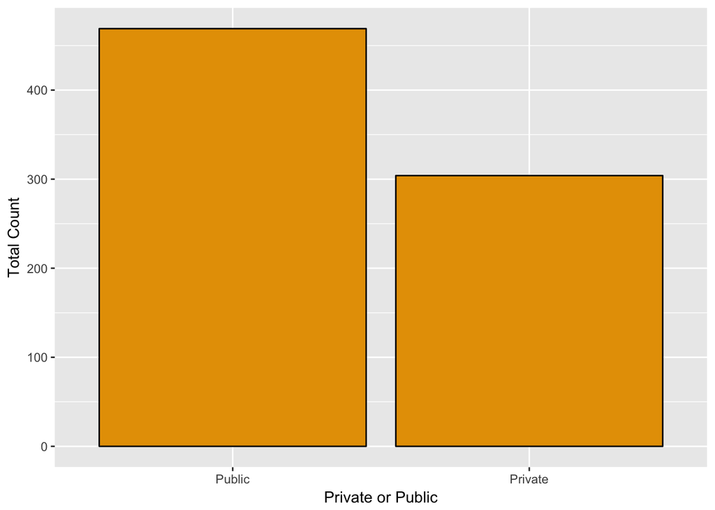

```r
#plot a bar chart showing the count of private and public schools participated
ggplot(school2012[NC == "Australia" & !is.na(SC01Q01)], aes(x=SC01Q01))+geom_bar(fill="#E69F00", colour="black")+labs(x="Private or Public", y="Total Count")
```

The following is a graph about the distribution of schools in Australia that participated:

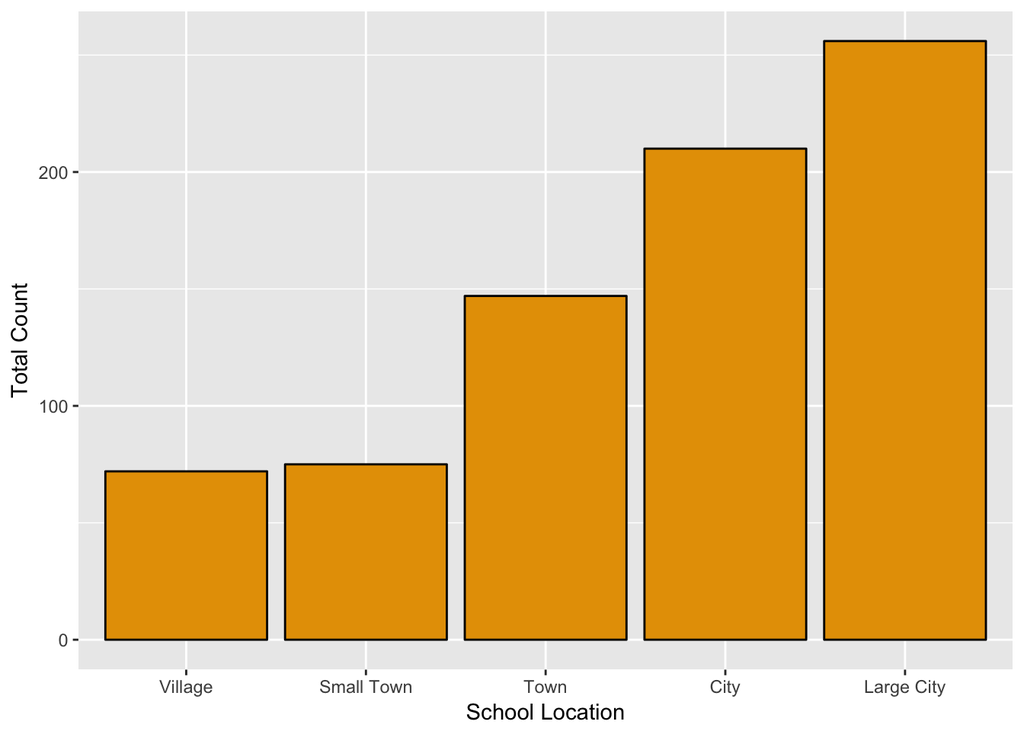

```r
#plot bar chart showing the school location for schools participated:
ggplot(school2012[NC == "Australia" & !is.na(SC03Q01)], aes(SC03Q01))+geom_bar(fill="#E69F00", colour="black")+labs(x="School Location", y="Total Count")
```

Now we want to look into the relationship between schools and weighted math performances from PV1MATH to PV5MATH:

```r
#filter out the data from Australia and select column SC03Q01(School location) and SchoolID
school_view <- school2012[NC =="Australia" & !is.na(SC03Q01)]
school_plot_data <- select(school_view, SC03Q01, SCHOOLID)

#merge two tables into one table for plotting use
plot_data <- merge(student_data, school_plot_data, by="SCHOOLID")

#a simple summary table
plot_data[, .(mu = mean(Mean_PVMATH, na.rm = T),
              sigma = sd(Mean_PVMATH, na.rm = T)),
              by = SC03Q01]
```

| SC03Q01 | mu | sigma |
| --- | --- | --- |
| Town | 484.0591 | 52.41388 |
| Large City | 518.5862 | 60.02301 |
| City | 500.7306 | 49.46786 |
| Village | 448.4095 | 69.54368 |
| Small Town | 472.2424 | 40.09360 |

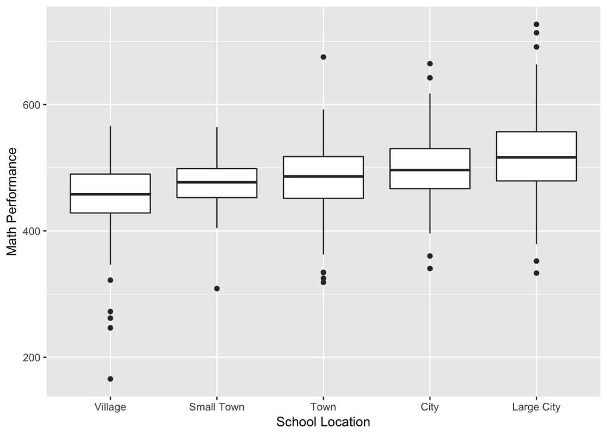

```r
#merge two tables: student_data and school_plot_data and create a boxplot
ggplot(plot_data, aes(x=factor(SC03Q01), y=Mean_PVMATH))+geom_boxplot()+labs(x="School Location", y="Math Performance")
```

```r
#run linear regression test
fit <- lm(Mean_PVMATH~SC03Q01, data=plot_data)
summary(fit)
```

```
##
## Call:
## lm(formula = Mean_PVMATH ~ SC03Q01, data = plot_data)
##
## Residuals:
##      Min       1Q   Median       3Q      Max
## -282.773  -34.668    0.743   35.401  208.365
##
## Coefficients:
##                   Estimate Std. Error t value Pr(>|t|)
## (Intercept)        448.410      6.496  69.033  < 2e-16 ***
## SC03Q01Small Town   23.833      9.094   2.621  0.00895 **
## SC03Q01Town         35.650      7.928   4.497 7.99e-06 ***
## SC03Q01City         52.321      7.527   6.951 7.85e-12 ***
## SC03Q01Large City   70.177      7.352   9.545  < 2e-16 ***
## ---
## Signif. codes:  0 '***' 0.001 '**' 0.01 '*' 0.05 '.' 0.1 ' ' 1
##
## Residual standard error: 55.12 on 755 degrees of freedom
## Multiple R-squared:  0.1362, Adjusted R-squared:  0.1316
## F-statistic: 29.76 on 4 and 755 DF,  p-value: < 2.2e-16
```

```r
#run ANOVA test
plot_anova <- aov(Mean_PVMATH~SC03Q01, data = plot_data)
summary(plot_anova)
```

```
##              Df  Sum Sq Mean Sq F value Pr(>F)
## SC03Q01       4  361608   90402   29.76 <2e-16 ***
## Residuals   755 2293569    3038
## ---
## Signif. codes:  0 '***' 0.001 '**' 0.01 '*' 0.05 '.' 0.1 ' ' 1
```

```r
#run Tukey test
tuk <- TukeyHSD(plot_anova)
tuk
```

```
##   Tukey multiple comparisons of means
##     95% family-wise confidence level
##
## Fit: aov(formula = Mean_PVMATH ~ SC03Q01, data = plot_data)
##
## $SC03Q01
##                           diff        lwr      upr     p adj
## Small Town-Village    23.83292 -1.0329231 48.69877 0.0676216
## Town-Village          35.64960 13.9706366 57.32857 0.0000781
## City-Village          52.32112 31.7389970 72.90324 0.0000000
## Large City-Village    70.17664 50.0721922 90.28109 0.0000000
## Town-Small Town       11.81668 -9.5692727 33.20264 0.5556866
## City-Small Town       28.48819  8.2149344 48.76145 0.0012437
## Large City-Small Town 46.34372 26.5555839 66.13185 0.0000000
## City-Town             16.67151  0.4643414 32.87868 0.0402473
## Large City-Town       34.52704 18.9309607 50.12311 0.0000000
## Large City-City       17.85552  3.8240010 31.88704 0.0048120
```

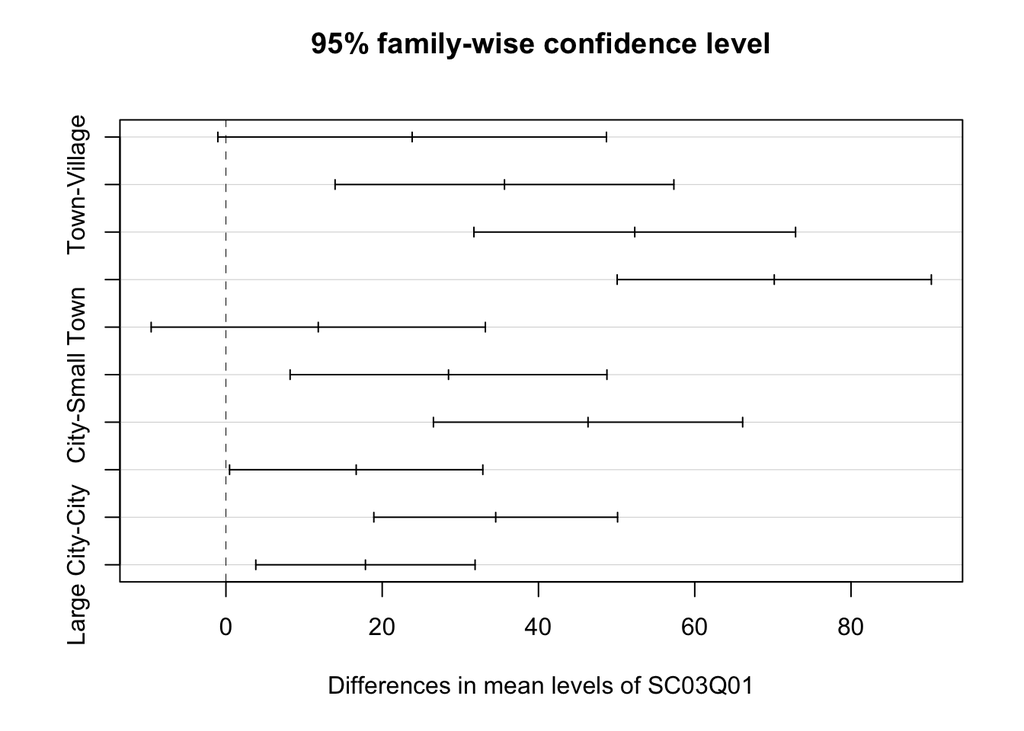

```r
plot(tuk)
```

The boxplot shows there is a significant difference in the mean score of students from different region of Australia. The graph implies that students from large city in Australia, for example, Sydney and Melbourne normally scores higher than students from a village. In the linear regression test, the p values are all smaller than 0.05 which implies that the store locations are highly related to a student’s math performance. In the ANOVA test, the F value is 29.76 and p-value is very small(less than 0.05). Which implies that there is a significant relationship between the school location and the scores in students’ math literacy. And since there are multiple(more than 2) factors in this dataset, we will run another tukey test to compare the differences between each paired groups. From the Tukey test above, telling from the column diff and p adj, some interesting facts can be able to conclude: 1. There is no significant discrepancy in performances between a Town school and a Small Town School since the p=0.55>0.05 and Small Town-Village since p=0.07>0.05. 2. There are significant discrepancy in math performace between City-Village, Large City-Village, Large City-Samll Town, Large City-Town, since the p value all equal to 0. These significant difference is shown in the plotted Tukey graph. Those pairs that are significantly different are those that does not across the 0 value.

```r
school_view <- school2012[NC =="Australia" & !is.na(SC01Q01)]
school_plot_data <- select(school_view, SC01Q01, SCHOOLID)

#merge two tables into one table for plotting use
plot_data <- merge(student_data, school_plot_data, by="SCHOOLID")

#a simple summary table
plot_data[, .(mu = mean(Mean_PVMATH, na.rm = T),
              sigma = sd(Mean_PVMATH, na.rm = T)),
              by = SC01Q01]
```

| SC01Q01 | mu | sigma |
| --- | --- | --- |
| Private | 521.0669 | 49.04944 |
| Public | 479.2423 | 59.25269 |

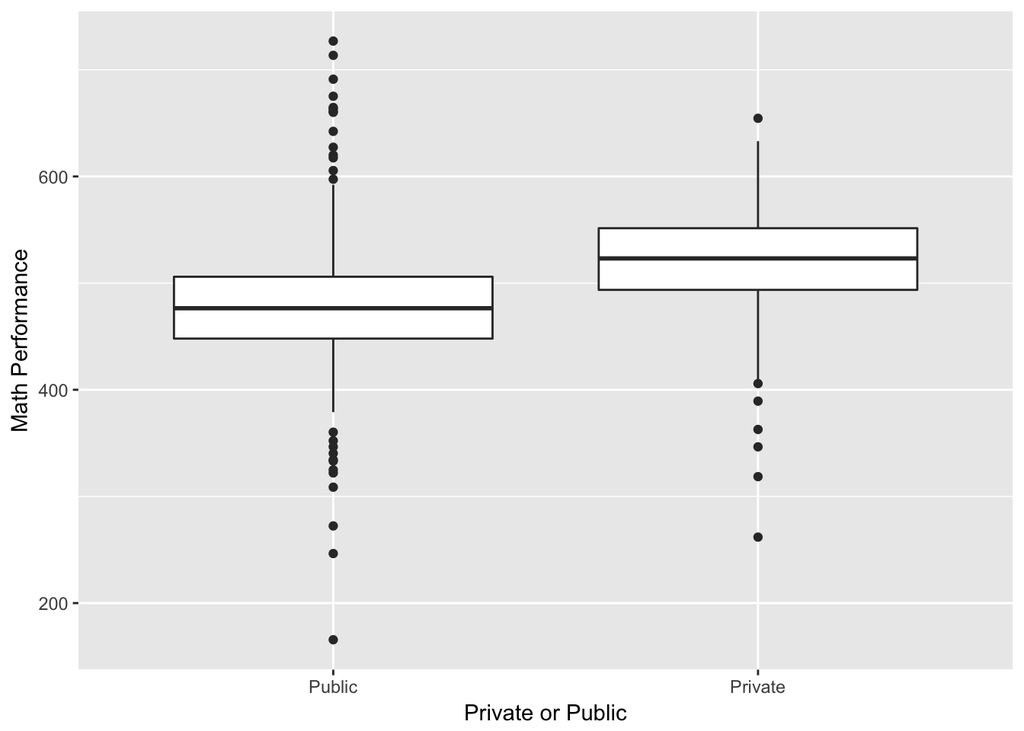

```r
#create a boxplot comparing the mean value
ggplot(plot_data, aes(x=factor(SC01Q01), y=Mean_PVMATH))+geom_boxplot()+labs(x="Private or Public", y="Math Performance")
```

```r
#run linear regression test
fit <- lm(Mean_PVMATH~SC01Q01, data=plot_data)
summary(fit)
```

```
##
## Call:
## lm(formula = Mean_PVMATH ~ SC01Q01, data = plot_data)
##
## Residuals:
##      Min       1Q   Median       3Q      Max
## -313.605  -29.561    0.133   28.136  247.709
##
## Coefficients:
##                Estimate Std. Error t value Pr(>|t|)
## (Intercept)     479.242      2.561  187.11   <2e-16 ***
## SC01Q01Private   41.825      4.084   10.24   <2e-16 ***
## ---
## Signif. codes:  0 '***' 0.001 '**' 0.01 '*' 0.05 '.' 0.1 ' ' 1
##
## Residual standard error: 55.47 on 771 degrees of freedom
## Multiple R-squared:  0.1197, Adjusted R-squared:  0.1186
## F-statistic: 104.9 on 1 and 771 DF,  p-value: < 2.2e-16
```

```r
#run ANOVA test
plot_anova <- aov(Mean_PVMATH~SC01Q01, data = plot_data)
summary(plot_anova)
```

```
##              Df  Sum Sq Mean Sq F value Pr(>F)
## SC01Q01       1  322649  322649   104.9 <2e-16 ***
## Residuals   771 2372064    3077
## ---
## Signif. codes:  0 '***' 0.001 '**' 0.01 '*' 0.05 '.' 0.1 ' ' 1
```

The boxplot shows there is a great difference in the mean score of students from different sectors of Australia. In the linear regression test, the p values are all smaller than 0.05 which implies that the whether the school is a private on or public one is highly related to a student’s math performance. The graph implies that students from private schools in Australia outperform the students from government/public schools. In the ANOVA test, the F value is 104.9 and p-value is very small(less than 0.05). Suggesting that there is a strong relationship between whether a school is private or public can affect the student’s score on math literacy. Since there are only two levels of factors in this test, we will not run a Tukey test like above.